# Analyzing wines physicochemical properties by Marcos Alves

# Introduction

In this project, I’m trying to identify what are the characteristics of good wine.

I’m using the public dataset **Wine Quality Datasets** - P. Cortez, A. Cerdeira, F. Almeida, T. Matos and J. Reis. Modeling wine preferences by data mining from physicochemical properties. In Decision Support Systems, Elsevier, 47(4):547-553, 2009. It contains two datasets, one for red wines and another for white wines.

[Here](http://www3.dsi.uminho.pt/pcortez/wine/) you can find more information and the files used in this project.

## Variables

- Fixed acidity: g(tartaric acid)/dm3
- Volatile acidity: g(acetic acid)/dm3
- Citric acid: g/dm3
- Residual sugar: g/dm3
- Chlorides: g(sodium chloride)/dm3 the amount of salt in the wine
- Free sulfur dioxide: mg/dm3
- Total sulfur dioxide: mg/dm3
- Density: g/cm3
- pH
- Sulphates:g(potassium sulphate)/dm3
- Alcohol: % vol.
- Quality: evaluated by a minimum of three sensory assessors (using blind tastes), classified in a scale from 0 (very bad) to 10 (excellent). The final sensory score is the median of these evaluations.

# Considerations

Wine certification assessed by sensory tests is very subjective, so it might be hard to find a clear correlation of the variables with the quality of the wine. This is an interesting [Vox video](https://www.youtube.com/watch?v=mVKuCbjFfIY) about wines taste and price.

For this project, I will use the white wine (winequality-white.csv) dataset.

# Data Analysis - White Wine Dataset

# Univariate

```
##  fixed.acidity    volatile.acidity  citric.acid     residual.sugar
##  Min.   : 3.800   Min.   :0.0800   Min.   :0.0000   Min.   : 0.600
##  1st Qu.: 6.300   1st Qu.:0.2100   1st Qu.:0.2700   1st Qu.: 1.700
##  Median : 6.800   Median :0.2600   Median :0.3200   Median : 5.200
##  Mean   : 6.855   Mean   :0.2782   Mean   :0.3342   Mean   : 6.391
##  3rd Qu.: 7.300   3rd Qu.:0.3200   3rd Qu.:0.3900   3rd Qu.: 9.900
##  Max.   :14.200   Max.   :1.1000   Max.   :1.6600   Max.   :65.800
##    chlorides       free.sulfur.dioxide total.sulfur.dioxide
##  Min.   :0.00900   Min.   :  2.00      Min.   :  9.0
##  1st Qu.:0.03600   1st Qu.: 23.00      1st Qu.:108.0
##  Median :0.04300   Median : 34.00      Median :134.0
##  Mean   :0.04577   Mean   : 35.31      Mean   :138.4
##  3rd Qu.:0.05000   3rd Qu.: 46.00      3rd Qu.:167.0
##  Max.   :0.34600   Max.   :289.00      Max.   :440.0
##     density             pH          sulphates         alcohol
##  Min.   :0.9871   Min.   :2.720   Min.   :0.2200   Min.   : 8.00
##  1st Qu.:0.9917   1st Qu.:3.090   1st Qu.:0.4100   1st Qu.: 9.50
##  Median :0.9937   Median :3.180   Median :0.4700   Median :10.40
##  Mean   :0.9940   Mean   :3.188   Mean   :0.4898   Mean   :10.51
##  3rd Qu.:0.9961   3rd Qu.:3.280   3rd Qu.:0.5500   3rd Qu.:11.40
##  Max.   :1.0390   Max.   :3.820   Max.   :1.0800   Max.   :14.20
##     quality
##  Min.   :3.000
##  1st Qu.:5.000
##  Median :6.000
##  Mean   :5.878
##  3rd Qu.:6.000
##  Max.   :9.000
```

Dataset summary

```
## 'data.frame':    4898 obs. of  12 variables:
##  $ fixed.acidity       : num  7 6.3 8.1 7.2 7.2 8.1 6.2 7 6.3 8.1 ...
##  $ volatile.acidity    : num  0.27 0.3 0.28 0.23 0.23 0.28 0.32 0.27 0.3 0.22 ...
##  $ citric.acid         : num  0.36 0.34 0.4 0.32 0.32 0.4 0.16 0.36 0.34 0.43 ...
##  $ residual.sugar      : num  20.7 1.6 6.9 8.5 8.5 6.9 7 20.7 1.6 1.5 ...
##  $ chlorides           : num  0.045 0.049 0.05 0.058 0.058 0.05 0.045 0.045 0.049 0.044 ...
##  $ free.sulfur.dioxide : num  45 14 30 47 47 30 30 45 14 28 ...
##  $ total.sulfur.dioxide: num  170 132 97 186 186 97 136 170 132 129 ...
##  $ density             : num  1.001 0.994 0.995 0.996 0.996 ...
##  $ pH                  : num  3 3.3 3.26 3.19 3.19 3.26 3.18 3 3.3 3.22 ...
##  $ sulphates           : num  0.45 0.49 0.44 0.4 0.4 0.44 0.47 0.45 0.49 0.45 ...
##  $ alcohol             : num  8.8 9.5 10.1 9.9 9.9 10.1 9.6 8.8 9.5 11 ...
##  $ quality             : int  6 6 6 6 6 6 6 6 6 6 ...
```

This is the structure of the dataset

```
##   fixed.acidity volatile.acidity citric.acid residual.sugar chlorides
## 1           7.0             0.27        0.36           20.7     0.045
## 2           6.3             0.30        0.34            1.6     0.049
## 3           8.1             0.28        0.40            6.9     0.050
## 4           7.2             0.23        0.32            8.5     0.058
## 5           7.2             0.23        0.32            8.5     0.058
## 6           8.1             0.28        0.40            6.9     0.050
##   free.sulfur.dioxide total.sulfur.dioxide density   pH sulphates alcohol
## 1                  45                  170  1.0010 3.00      0.45     8.8
## 2                  14                  132  0.9940 3.30      0.49     9.5
## 3                  30                   97  0.9951 3.26      0.44    10.1
## 4                  47                  186  0.9956 3.19      0.40     9.9
## 5                  47                  186  0.9956 3.19      0.40     9.9
## 6                  30                   97  0.9951 3.26      0.44    10.1
##   quality
## 1       6
## 2       6
## 3       6
## 4       6
## 5       6
## 6       6
```

These are the first 6 rows of each variable

```
##                              [,1]
## volatile.acidity     -0.194722969
## citric.acid          -0.009209091
## residual.sugar       -0.097576829
## chlorides            -0.209934411
## free.sulfur.dioxide   0.008158067
## total.sulfur.dioxide -0.174737218
## density              -0.307123313
## pH                    0.099427246
## sulphates             0.053677877
## alcohol               0.435574715
## quality               1.000000000
```

The correlation between each variable and quality

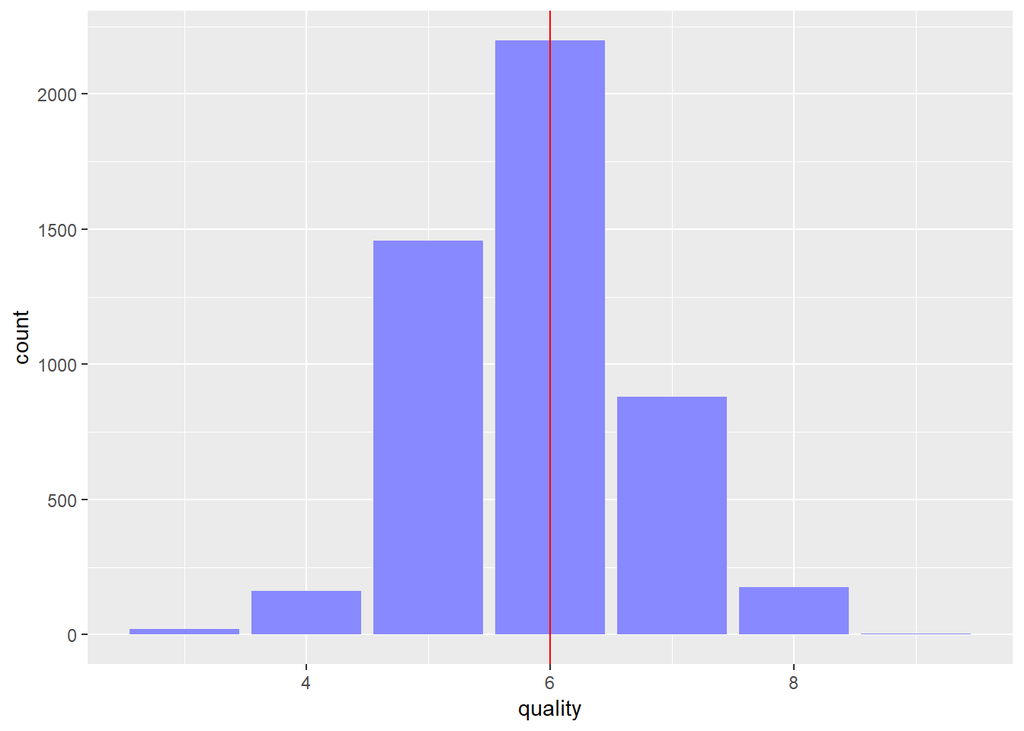

Most wines have a quality of 6 and the best variable for quality correlation is alcohol.

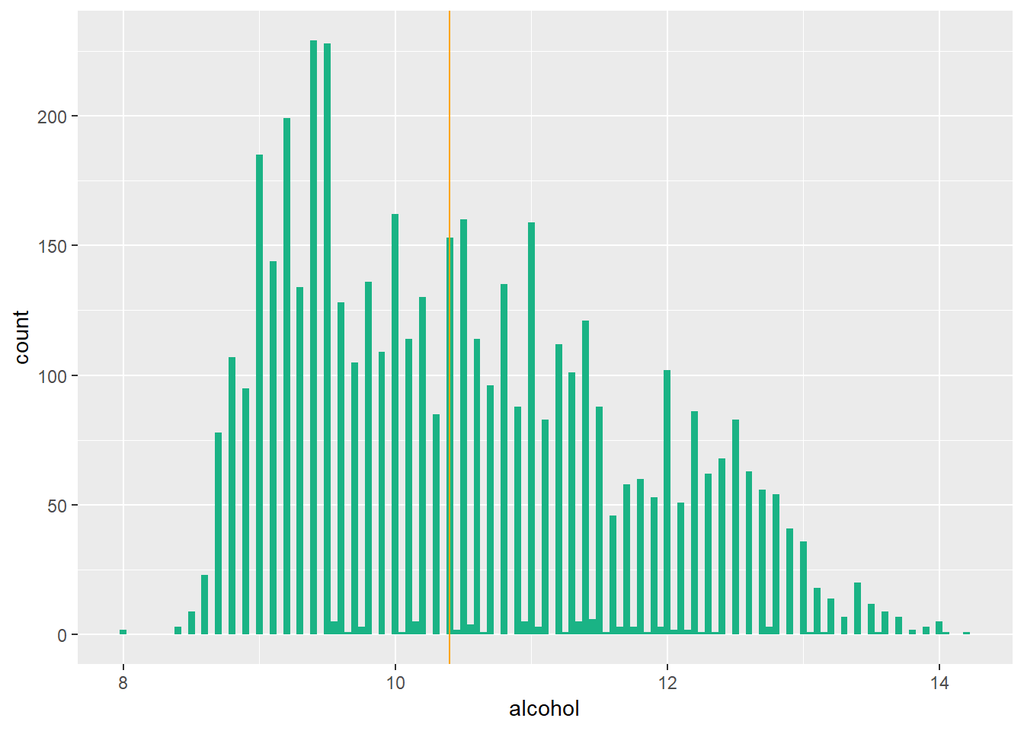

The histogram of alcohol

There are 4898 observations for this dataset (not so large) and all variables are numbers, except for the quality variable, which is an integer. Later I’ll transform the quality variable to factor, so it can be treated as a label.

For this analysis I’m not considering the outliers, so I can make the analysis more robust.

The residual sugar has some unusual distribution, where there is a high peak below 5 g/dm3, and also the alcohol seems to have a more low variance distribution.

For the quality distribution, the majority of values are between 5 and 7, and very small quantities for the remaining score values, making it a low variance distribution. This is an indication that most of these brand wines have a good score.

The correlation of the variables with quality shows that these variables don’t have a high value. The highest value is 0.44 for alcohol and then the inverse correlation with density (-0.31). These variables might be the best for the analysis.

# Bivariate

#### Let’s create a new column with the quality values as labels so we can create a boxplot by quality.

```
white$scale <- as.factor(white$quality)
```

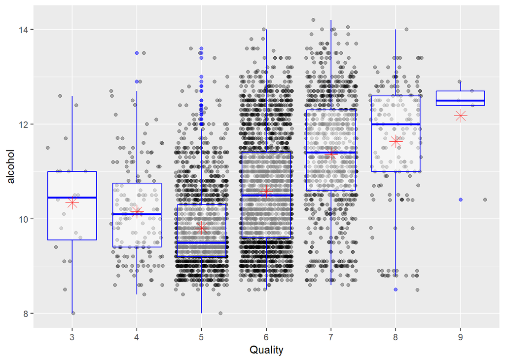

> There is a clear indication of the correlation of alcohol and quality above the score of 6

### Alcohol x Quality:

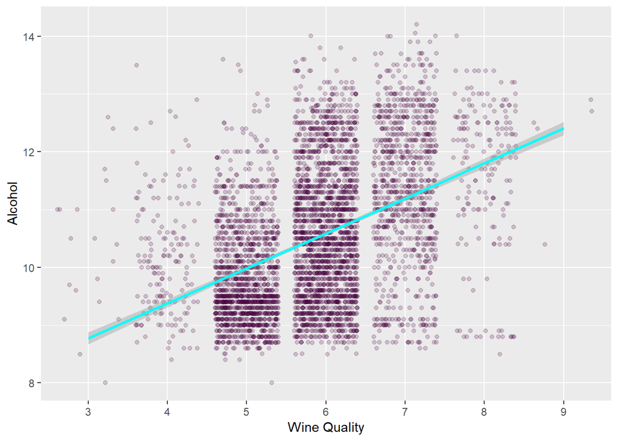

### Alcohol and Quality Correlation:

```
## [1] 0.4355747
```

## ggpairs

using the ggpair function we can have a look on all the relations between the variables

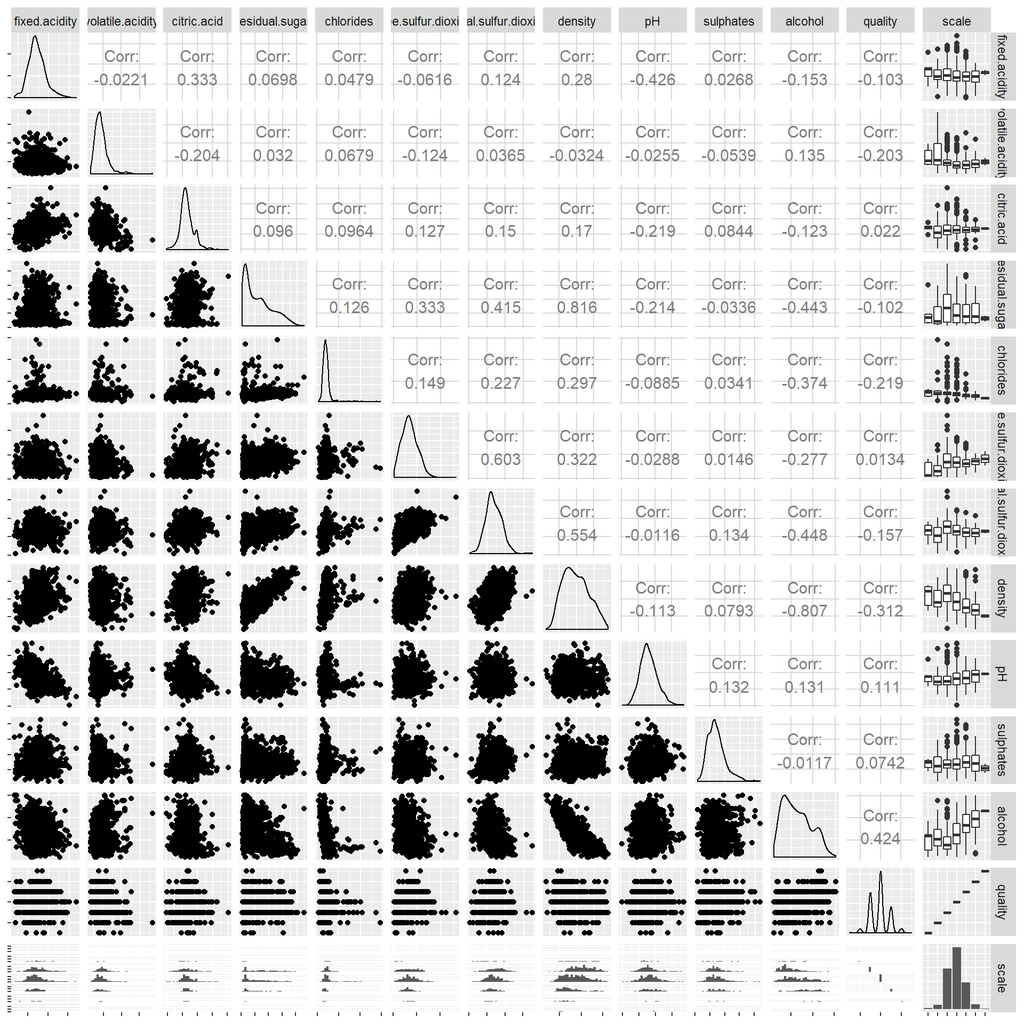

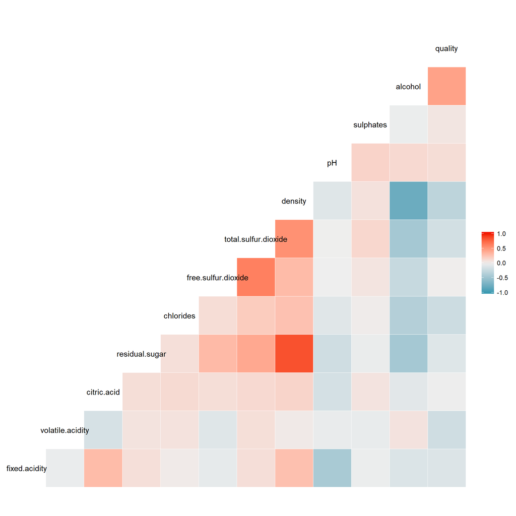

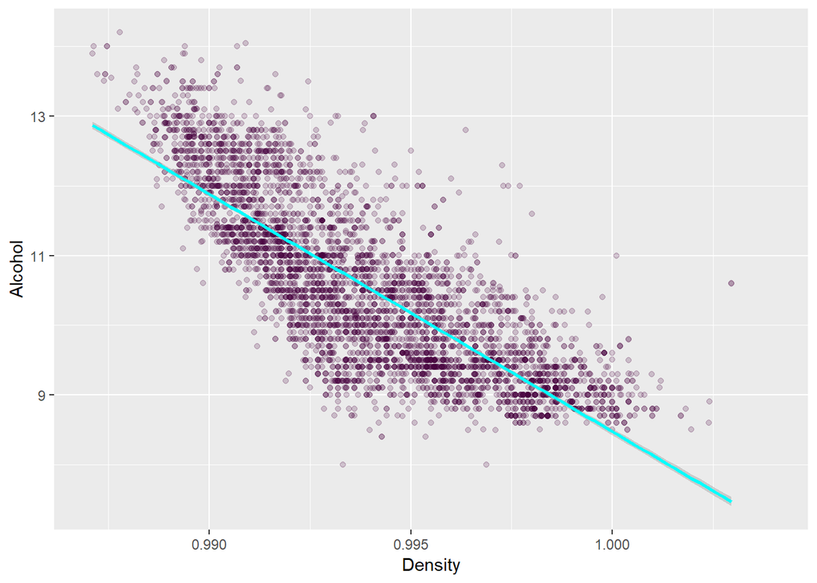

This plot has a good correlation, where the data is well distributed along the smooth line, and has a good inverse slope.

```r
cor(white$alcohol, white$density)
```

```
## [1] -0.7801376
```

### Citric Acid x Quality:

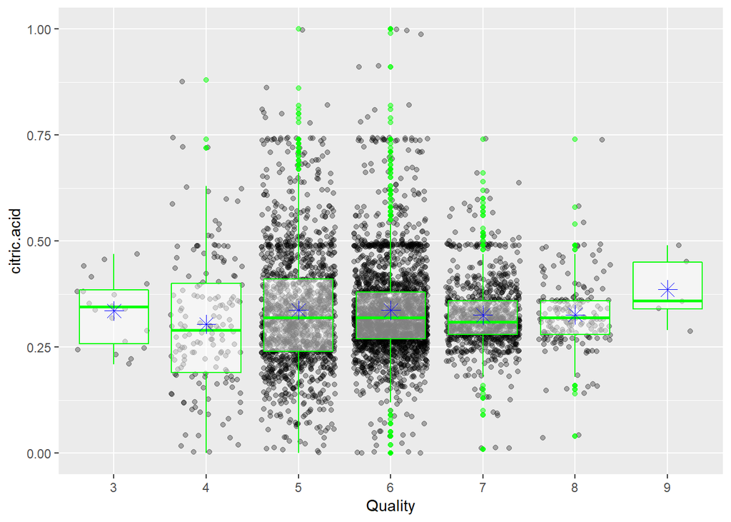

Most values of Citric Acid are in the same range, but in the score of 9 it seems to be a bit higher.

### Free sulfur dioxide x Quality:

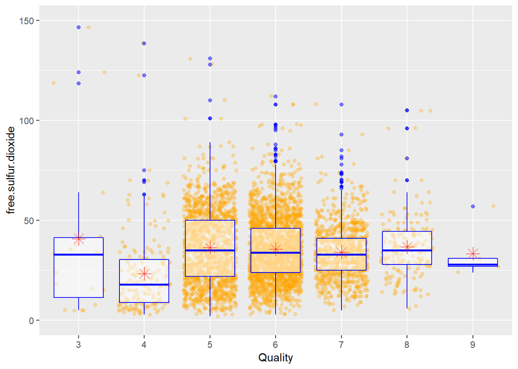

Values above the quality of four are close to 35. There are a few outliers with hight values of free SO2 for the quality of 3, so I ajusted the y axis to have a better view where most of the values are. It also seems that the value of free SO2 has a small decrease above the quality of 8.

### pH x Quality:

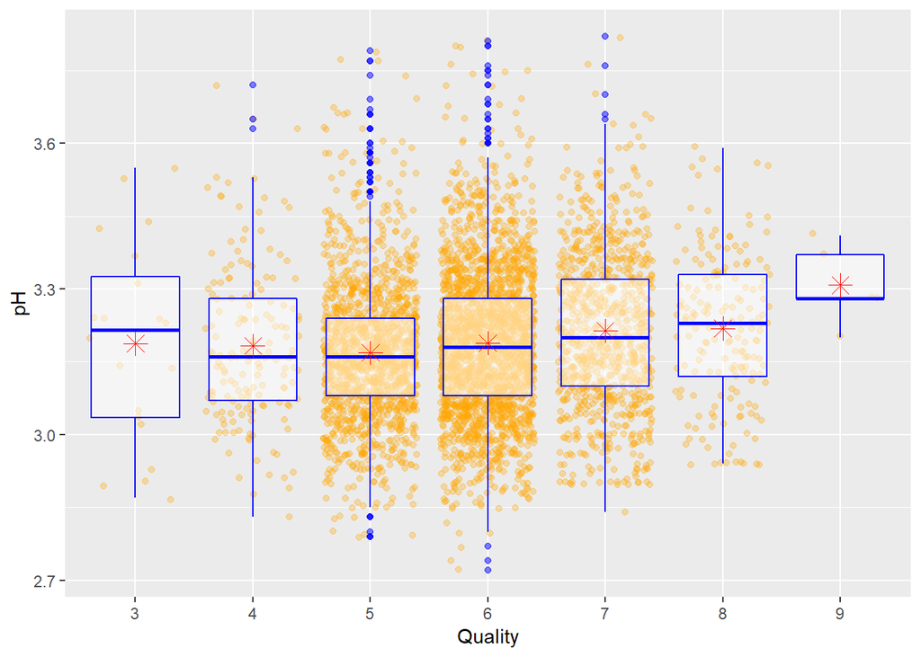

There is a slight increase in pH as quality gets higher

pH seems to have some correlation with quality, so let’s see what variables might affect it:

```
##                               [,1]
## volatile.acidity     -0.0319153683
## citric.acid          -0.1637482114
## residual.sugar       -0.1941334540
## chlorides            -0.0904394560
## free.sulfur.dioxide  -0.0006177961
## total.sulfur.dioxide  0.0023209718
## density              -0.0935914935
## pH                    1.0000000000
## sulphates             0.1559514973
## alcohol               0.1214320987
## quality               0.0994272457
```

All the correlations seem low.

### residual.sugar x pH:

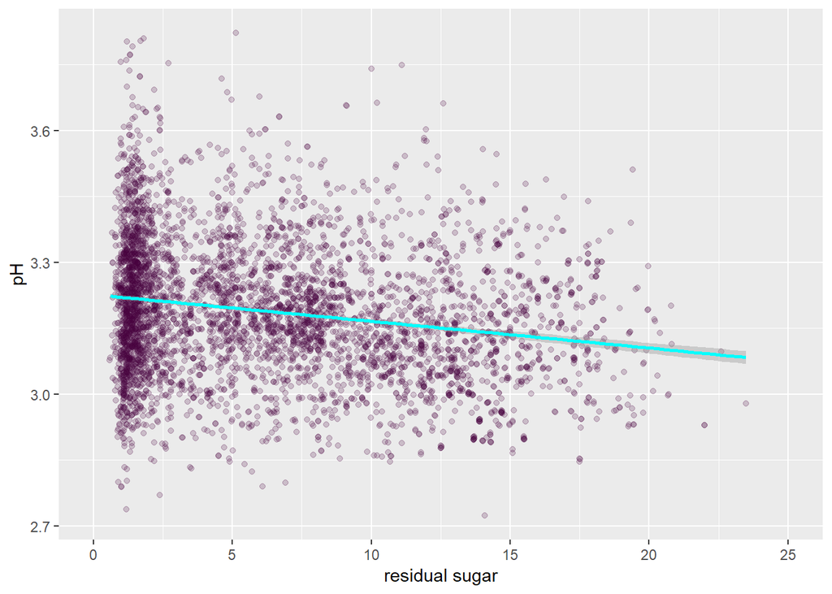

Here we can see the high peak from the Univariate analysis for the residual.sugar variable. This correlation looks weak.

### citric.acid x pH:

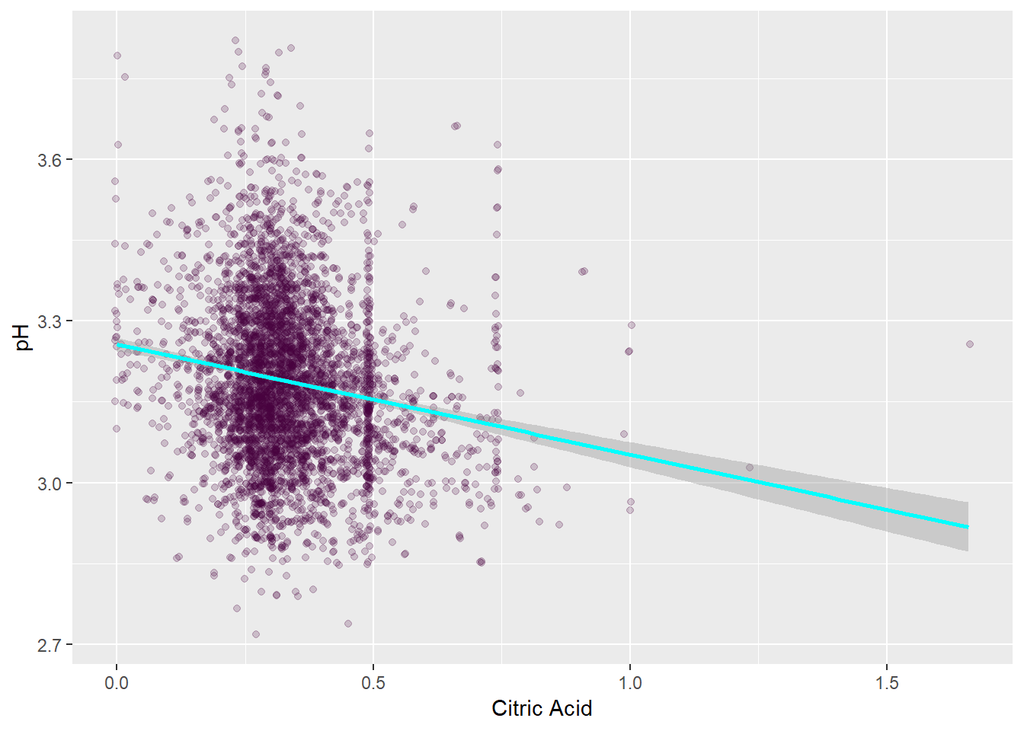

In this plot most values are around 0.3 in the Citric Acid axis and a few pontual values in the 0.5 and 0.75, creating the shape of a line.

### sulphates x pH:

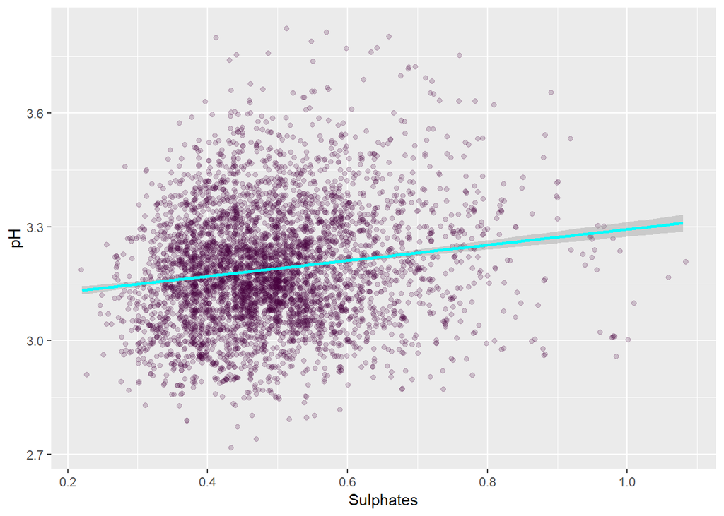

In this plot the distribution of data looks a bit better. These three plots of the relation of pH with other variables confirms that most correlations of pH are low. Maybe using another variable we’ll be able to find some pattern.

### Volatile Acidity x Quality:

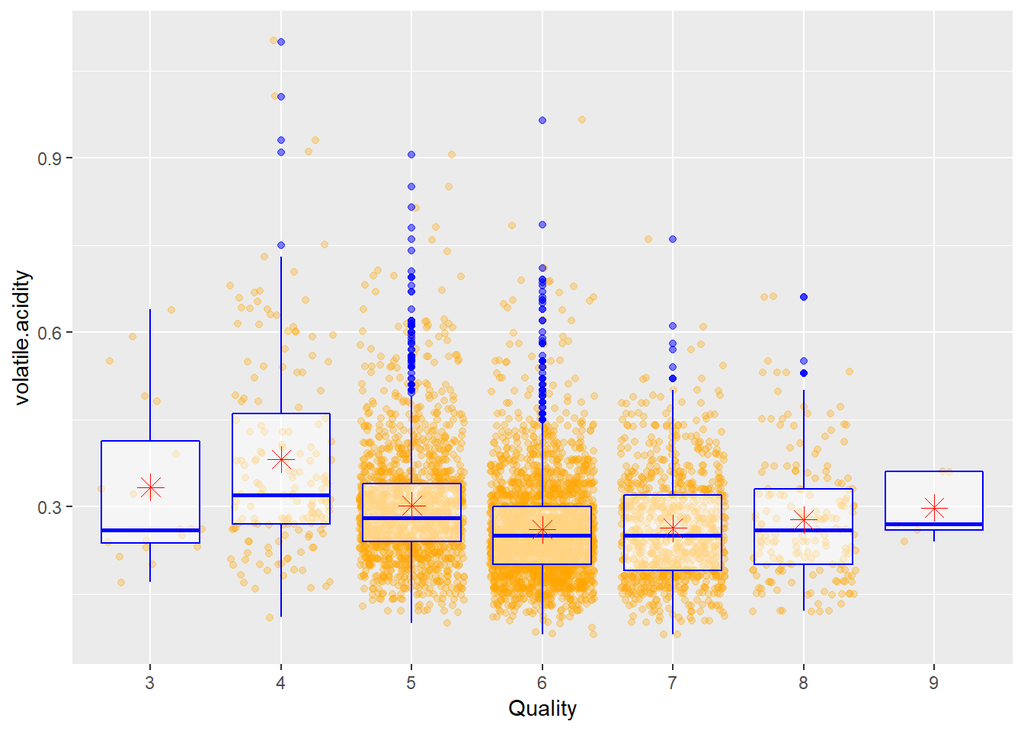

For Volatile Acidity, the values are below 30 for values of quality above 4, and the means look constant.

### Chlorides x Quality:

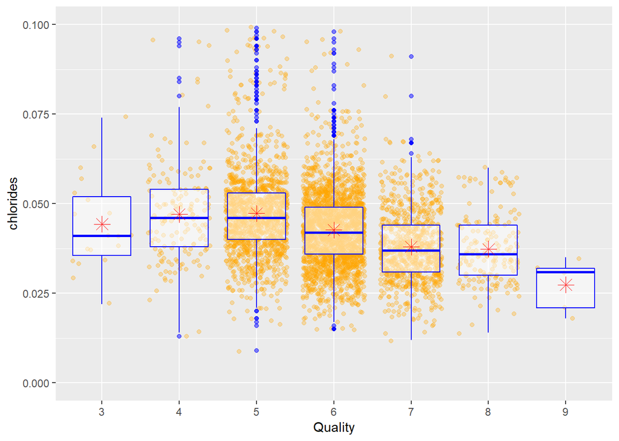

This plot has a small range of values for Chlorides, so I ajusted the y axis to have a better view. With this change, it is easier to see a decline in Chlorides as the quality increases. This corroborates with the early analysis of correlations, where this plot has a value of -0.21.

### Residual Sugar x Chlorides

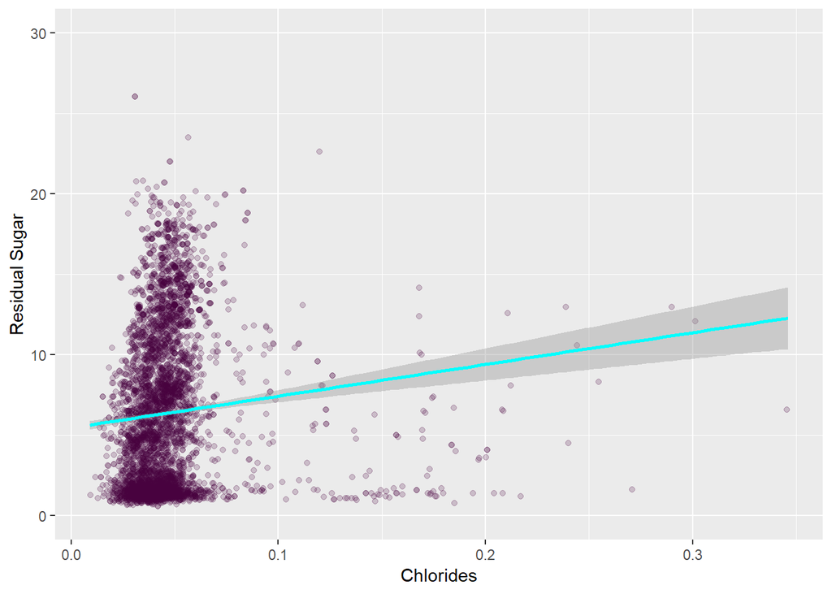

Here, the residual.sugar doesn’t look to be affected by the Chlorides, where most of the data makes almost a vertical shape.

There is an unusual pattern, where some values of very low quality wines are almost the same of good quality wines, as seen in volatile.acidity x Quality; pH x Quality; free.sulfur.dioxide; citric.acid x Quality.

Using a third variable in the plot might help seeing better the relation of these variables with quality.

# Multivariate

### Density x Alcohol

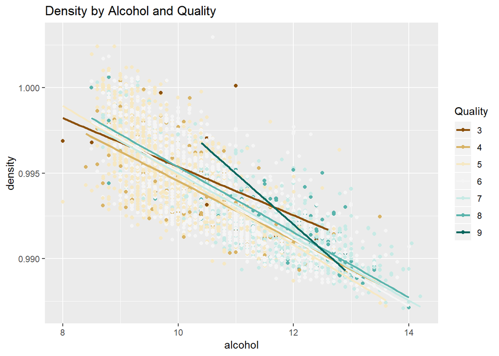

## Density x Residual Sugar

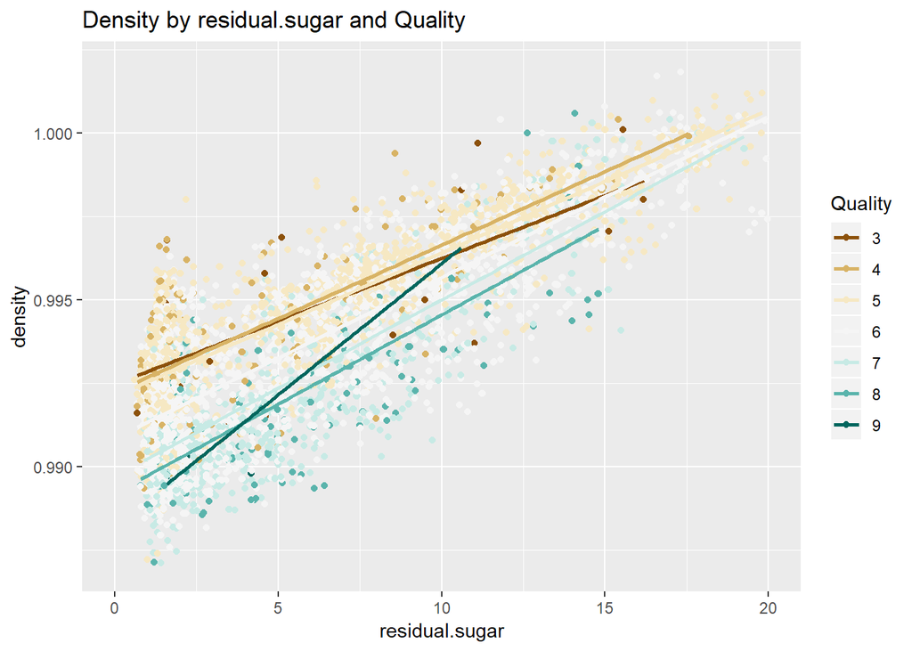

In the second Multivariate plot, we can see the density and residual.sugar correlation. There is a nice distinction of colors, separated by the smooth line. Most higher quality wines are below the line, thus we might argue that testers prefer a higher residual.sugar/density ratio. In this plot the score of nine also has a better corellation for the variables (looks close to 1).

### Sugar x pH

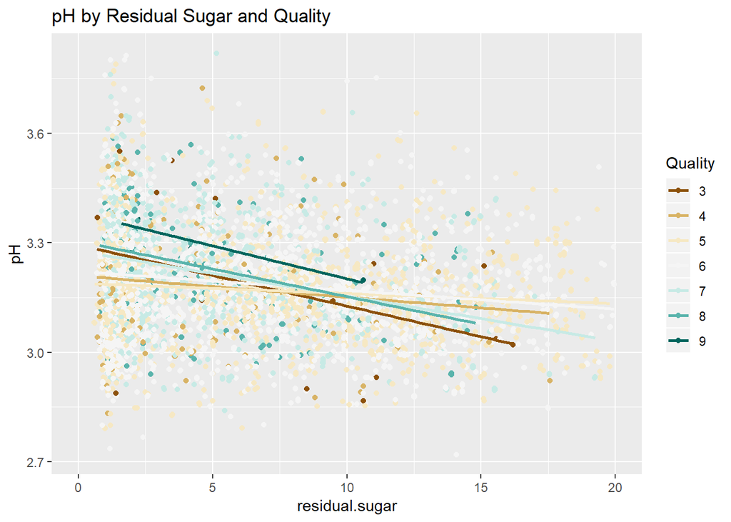

This plot does not add much value for the analysis. The regression lines don’t have such a good slope and the colors are randomly distributed, with no well defined pattern, though the regression line for nine is separate from the rest.

### Citric Acid and pH

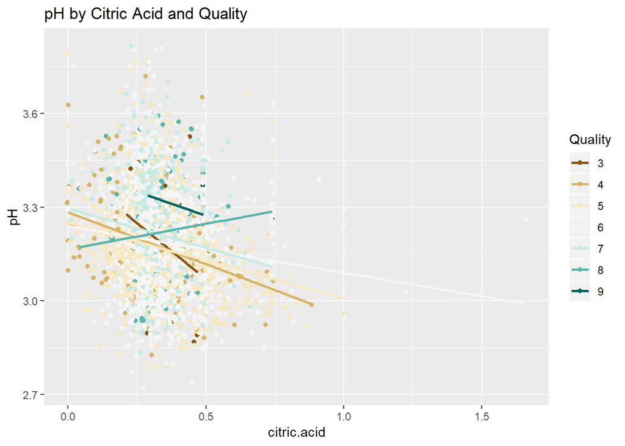

Here we can see that there is a interval in the Citric Acid Above 0.25 and below 0.5 where the wine quality is considerably higher and the pH doesn’t interfere so much. The reggresion lines show some correlation for the score of eight, inverse correlation for seven and 4, and good inverse correlation for scores of 3 . This might indicate that low values of citric acid are found in low quality wines.

## Total Sulfur Dioxide x Free Sulfur Dioxide

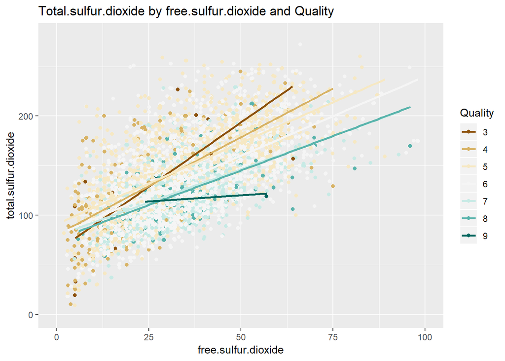

Some correlation is notible between these two variables. We can distinguish an area where there is a concentration of most green dots, in the lower part of the scatter points, wich indicates a preference for a higher free.sulfur.dioxide/total.sulfur.dioxide ratio. Maybe there is some stage in the process of winemaking that directs affects this. There is a interesting information about the regression line of scores of nine, where it is almost horizontal. Maybe really good quality wines don’t get affected by this correlation.

### pH x Alcohol

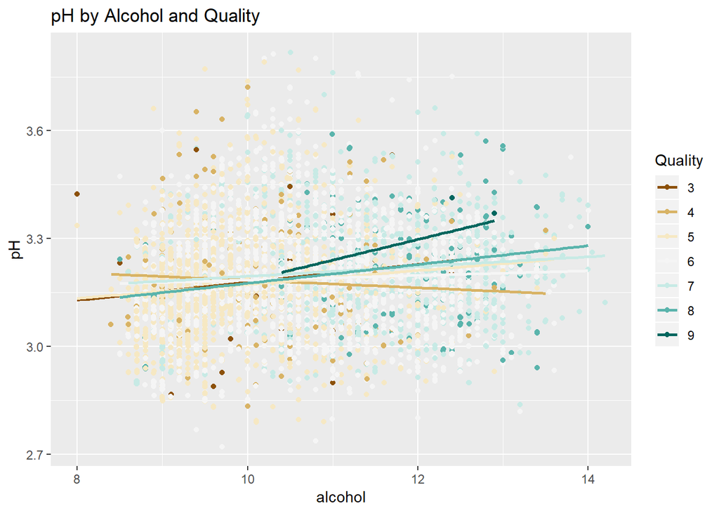

In this plot, the correlation between pH and alcohol is very low, and the quality is guided mainly by the alcohol quantity. Again we can notice that quality values iqual nine have some correlation with these variables.

### pH x Volatile Acidity

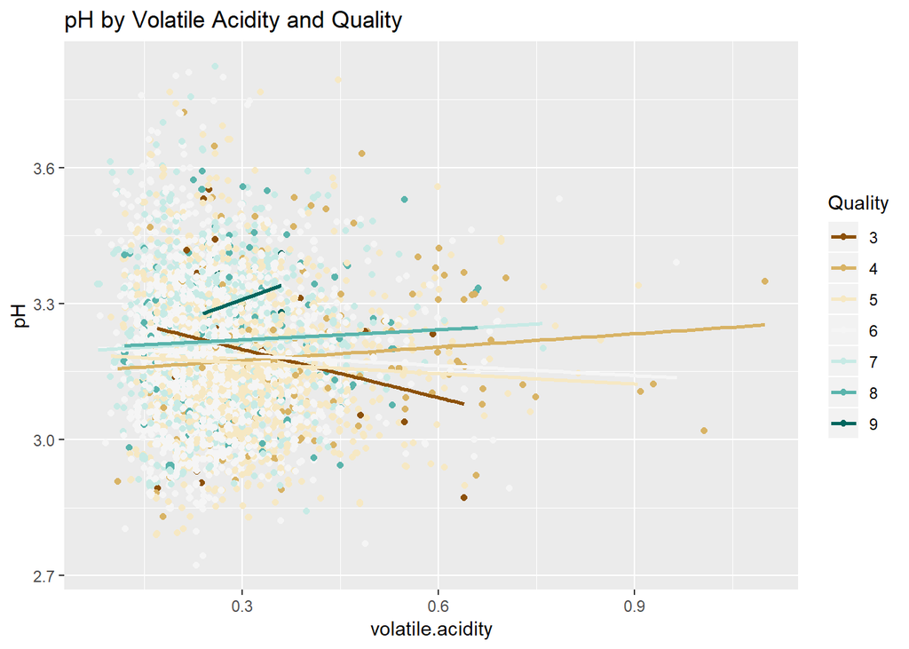

In this plot I was surprise by this noticeable distinction. For the extreme values of quality (3 and 9), these variables have an oposite regression line. The best quality wines have a correlation of pH and Volatile Acidity positive and the lowest quality wines have an inverse correlation, and the other values don’t have expressive correlations. Also there are some color region distinction for the data points.

### pH x sulphates

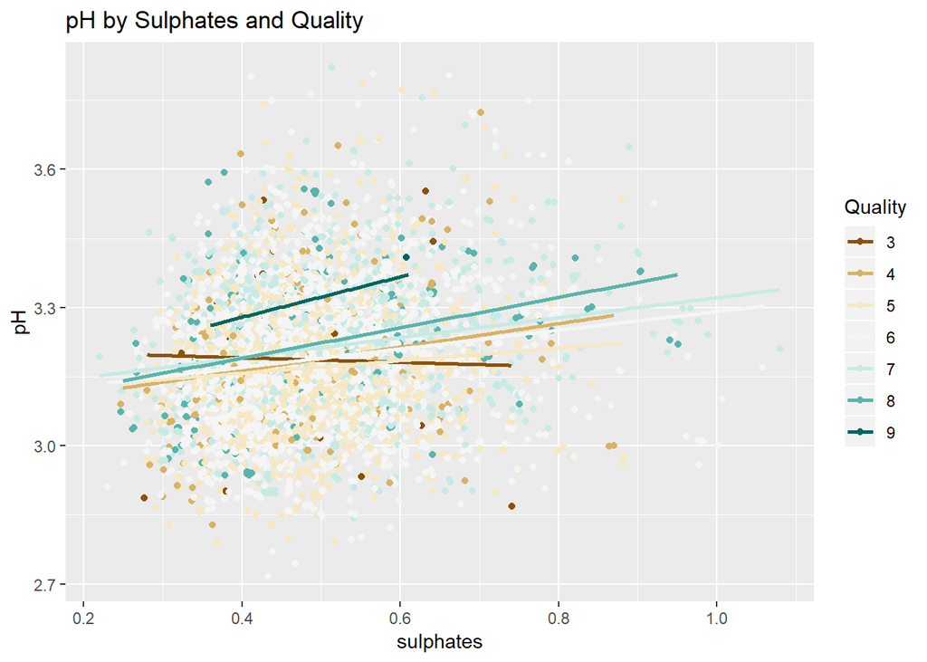

In this plot the correlation between the variables is low but the regression line for nine separates from the rest and there is the oposite correlation for the extreme values of quality.

# Final Plots and Summary

## Plot One

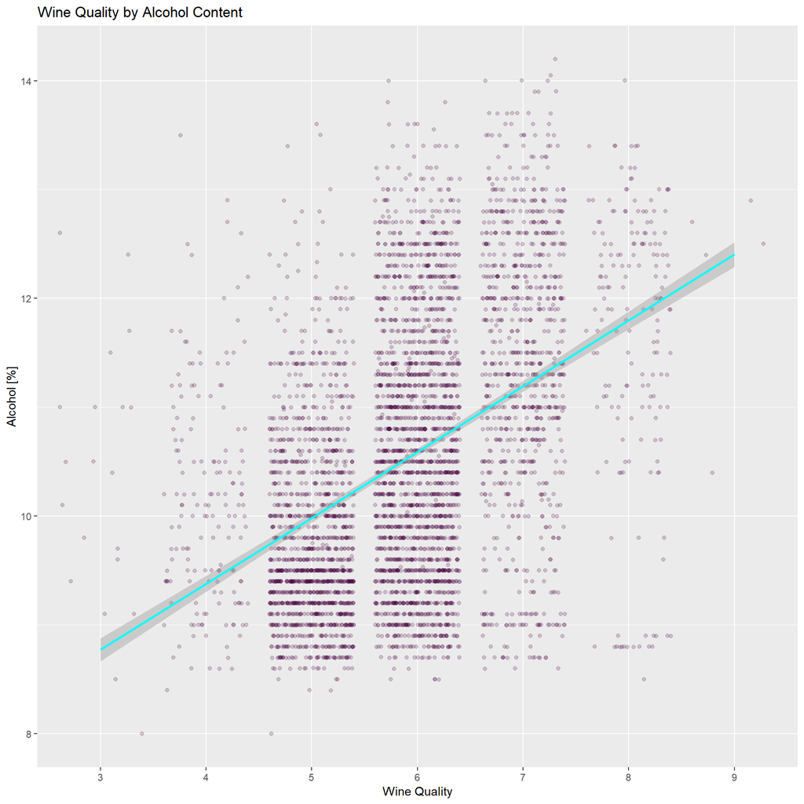

### This was my first plot because of the quick alanysis of the correlation between the variables and quality. Alcohol got a score well above the others. I think it is a good plot because it shows a direct influence of a substance in the quality of white wines.

## Plot Two

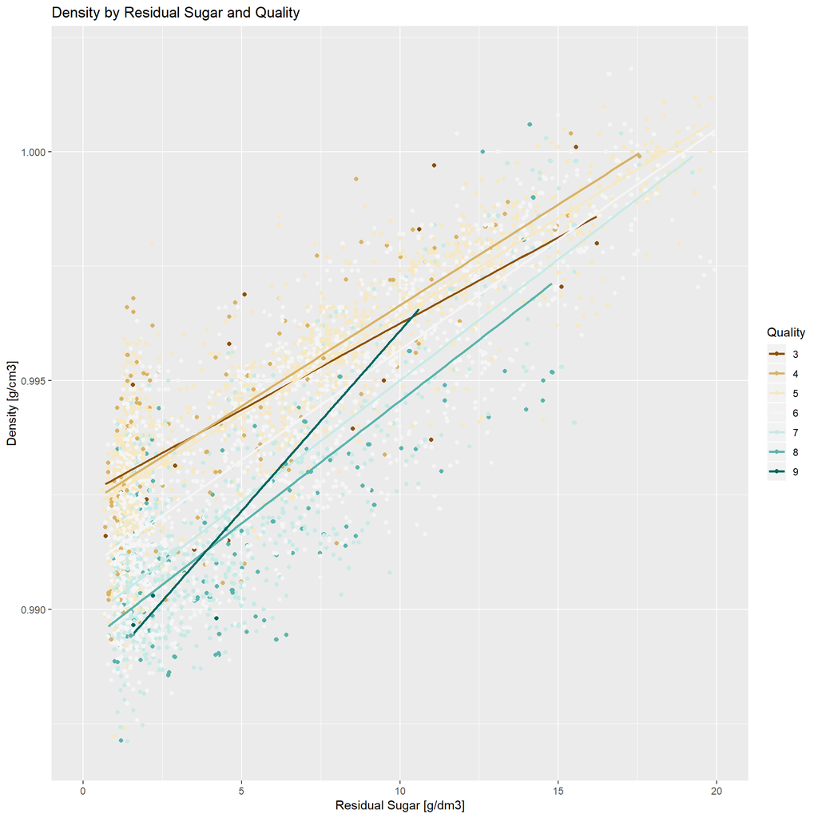

### For me this plot has the best correlation between the variables and it shows clearly a separation of good and bad wines. Also the regression line for the quality value of 9 indicates a very good correlation between Density and Residual sugar. I would strongly recommend to use this plot for selecting a good white wine (with a high value of alcohol, of course).

## Plot Three

[figure not shown]

### This plot was the one that I’ve got the most surprised. It was the first one the I notice a clear oposite correlation for the extreme values of quality. Even though this plot gives some good insight, I wouldn’t use it for making decisions because the distribution of quality is very low for this values and the bulk of the data is in the 5-7 range.

# Reflection

These are only the most noticeable physical features that could influence the quality of white wines found on this dataset. There are many other variables that could have an influence on the quality of a wine. I used the ggpairs function to help me find the most relevant features.

Even though the dataset is not so large and wine quality classification is very subjective, there are some correlations between the physicochemical properties that we can notice. The most noticeable is the alcohol %. Higher quality wines have a higher percentage of alcohol, which is correlated with lower density and a lower residual sugar proportion. All of these features must have a considerable impact on the color, smell, and taste of the wine.

These are values range I would pick for selecting a good whine:

- Fixed acidity: 6-7 g(tartaric acid)/dm3
- Volatile acidity: 0.20-0.35 g(acetic acid)/dm3
- Citric acid: 0.25-0.50 g/dm3
- Residual sugar: 1-6 g/dm3
- Chlorides: 0.03-0.04 g(sodium chloride)/dm3
- Free sulfur dioxide: 30-50 mg/dm3
- Total sulfur dioxide: 100-120 mg/dm3
- Density: 0.988-0.991 g/cm3
- pH: 3.2-3.3
- Sulphates:0.4-0.8 g(potassium sulphate)/dm3
- Alcohol: above 11 % vol.

In addition to this project, it would be interesting to use some machine learning algorithm to analyze this dataset and also analyze the red wine dataset for comparison.